# Data manipulation with dplyr

Susie Irons

21/01/2021

## Chapter 1 - Transforming data with dplyr

### Section 1 - The counties dataset

#### 2015 USA Census

- County = subregion of a state
- Glimpse allows you to see a few observations in all columns

```r
glimpse(counties)
```

```
Rows: 3,082
Columns: 6
$ name      <chr> "alabama,autauga", "alabama,baldwin", "alabama,barbou...
$ total.pop <dbl> 54571, 182265, 27457, 22915, 57322, 10914, 20947, 118...
$ white     <dbl> 77.2, 83.5, 46.8, 75.0, 88.9, 21.9, 54.1, 73.6, 58.1,...
$ black     <dbl> 19.3, 10.9, 47.8, 22.9, 2.5, 71.0, 44.2, 22.2, 39.9, ...
$ hispanic  <dbl> 2.4, 4.4, 5.1, 1.8, 8.1, 7.1, 0.9, 3.3, 1.6, 1.2, 7.8...
$ asian     <dbl> 0.9, 0.7, 0.4, 0.1, 0.2, 0.2, 0.8, 0.7, 0.5, 0.2, 0.3...
```

#### Select

- Extracts only particular variables from a dataset

|  | name | total.pop |
| --- | --- | --- |
| 1 | alabama,autauga | 54571 |
| 2 | alabama,baldwin | 182265 |
| 3 | alabama,barbour | 27457 |
| 4 | alabama,bibb | 22915 |
| 5 | alabama,blount | 57322 |
| 6 | alabama,bullock | 10914 |
| 7 | alabama,butler | 20947 |
| 8 | alabama,calhoun | 118572 |
| 9 | alabama,chambers | 34215 |
| 10 | alabama,cherokee | 25989 |

[output cut: 990 more lines]

#### Creating a new table

- Assignment can be used to create a new table

|  | name | total.pop |
| --- | --- | --- |
| 1 | alabama,autauga | 54571 |
| 2 | alabama,baldwin | 182265 |
| 3 | alabama,barbour | 27457 |
| 4 | alabama,bibb | 22915 |
| 5 | alabama,blount | 57322 |
| 6 | alabama,bullock | 10914 |
| 7 | alabama,butler | 20947 |
| 8 | alabama,calhoun | 118572 |
| 9 | alabama,chambers | 34215 |
| 10 | alabama,cherokee | 25989 |

[output cut: 990 more lines]

### Section 2 - The filter and arrange verbs

#### Arrange

- Orders selected variable from smallest to largest
- Useful finding the most interesting observations in the dataset

| name | total.pop |
| --- | --- |
| texas,loving | 82 |
| texas,king | 286 |
| texas,kenedy | 416 |
| nebraska,arthur | 460 |
| nebraska,blaine | 478 |
| montana,petroleum | 494 |
| nebraska,mcpherson | 539 |
| nebraska,grant | 614 |
| nebraska,loup | 632 |
| texas,borden | 641 |

[output cut: 990 more lines]

- Arrange in descending order

| name | total.pop |
| --- | --- |
| california,los angeles | 9818605 |
| illinois,cook | 5194675 |
| texas,harris | 4092459 |
| arizona,maricopa | 3817117 |
| california,san diego | 3095313 |
| california,orange | 3010232 |
| new york,kings | 2504700 |
| florida,dade | 2496435 |
| texas,dallas | 2368139 |
| new york,queens | 2230722 |

[output cut: 990 more lines]

#### Filter

- Extract only particular observations from a dataset, based on a condition
- Note the code below won’t run as the dataset doesn’t contain a ‘state’ column
- Can filter on logicals (<, >, <=, >=)
- Can combine multiple conditions in a filter by separating with a comma

```r
counties_select %>%
  arrange(desc(total.pop)) %>%
  filter(state == 'New York')
```

### Section 3 - Mutate

- The mutate verb can be used to add new variables or change existing ones

```r
counties_select %>%
  mutate(unemployed_population = population * unemployment / 100)
```

## Chapter 2 - Aggregating data

### Section 1 - The count verb

#### Count

- Counts total data

```r
counties %>%
  count()
```

- Total counties in each state

```r
counties %>%
  count(state)
```

#### Count and sort

- Often combine with sort to find most common observations

```r
counties %>%
  count(state, sort=TRUE)
```

- Sorts in desc order

#### Add weight

```r
counties %>%
  count(state, wt = popluation, sort=TRUE)
```

- Adds up the population of each county

### Section 2 - The group by, summarise and ungroup verbs

#### Group by and summarise

- Count is a case of a more general set of verbs
- Summarise takes many observations and reduces to a single figure

```r
counties %>%
  summarize(total_population = sum(population))
```

#### Aggregate and summarise

- Can define multiple variables
- Can aggregate in different ways
- Summary functions:
  - sum()
  - mean()
  - median()
  - min()
  - max()
  - n() - group size

#### Aggregate within groups

```r
counties %>%
  group_by(state) %>%
  summarize(total_pop = sum(population),
            average_unemployment = sum(unemployment)) %>%
  arrange(desc(average_unemployment))
```

- Useful to add an arrange to focus on most notable examples
- You can group by multiple columns at the same time

```r
counties %>%
  group_by(state, metro) %>%
  summarize(total_pop = sum(population))
```

- If you don’t want to keep state as a group you can add ungroup()

```r
counties %>%
  group_by(state, metro) %>%
  summarize(total_pop = sum(population)) %>%
  ungroup()
```

#### Section 3 - The top_n verb

- Useful for keeping the most extreme observations from each group
- Operates on a grouped table
- Take number of obs and column want to weigh by

```r
counties_selected <- counties %>%
  select(state, county, population, unemployment, income)

counties_selected %>%
  group_by(state) %>%
  top_n(1, population)
```

- Finds the county with the highest population in each state
- n can be any number
- Often used when creating graphs - when interested in pulling extreme examples

## Chapter 3 - Selecting

### Selecting

#### Select a range

```r
counties %>%
  select(state, county, drive:work_at_home) %>%
  arrange(drive)
```

#### Contains

- Select helpers - functions that specify criteria for choosing columns
- Take strings - in quotes

```r
counties %>%
  select(state, county, contains("work"))
```

#### Starts with

- Selects only cols that start with a particular prefix

```r
counties %>%
  select(state, county, starts_with("income"))
```

#### Other helpers

- contains()
- starts_with()
- ends_with()
- last_col()

For more - `? select helpers`

#### Removing a variable

```r
counties %>%
  select(-census_id)
```

### Section 2 - The rename verb

```r
counties_selected <- counties %>%
  select(state, county, population, unemployment)

counties_selected %>%
  rename(unemployment_rate = unemployment)
```

#### Combine verbs

- Can be done as a part of select

```r
counties_selected %>%
  select(state, county, population, unemployment_rate = unemployment)
```

### Section 3 - The transmute verb

#### Transmute

- Combination - select & mutate
- Returns a subset of columns that are transformed and changed

```r
counties %>%
  transmute(state, county, fraction_men = men / population)
```

#### Summary

| Properties | Keeps only specified variables | Keeps other variables |
| --- | --- | --- |
| Can’t change values | select | rename |
| Can change values | transmute | mutate |

## Chapter 4 - Case study - the babynames dataset

| year | name | n |
| --- | --- | --- |
| 1880 | Mary | 7065 |
| 1880 | Anna | 2604 |
| 1880 | Emma | 2003 |
| 1880 | Elizabeth | 1939 |
| 1880 | Minnie | 1746 |
| 1880 | Margaret | 1578 |
| 1880 | Ida | 1472 |
| 1880 | Alice | 1414 |
| 1880 | Bertha | 1320 |
| 1880 | Sarah | 1288 |

[output cut: 990 more lines]

#### Frequency of a name

| year | name | n |
| --- | --- | --- |
| 1882 | Susannah | 7 |
| 1884 | Susannah | 8 |
| 1885 | Susannah | 7 |
| 1886 | Susannah | 5 |
| 1887 | Susannah | 7 |
| 1891 | Susannah | 5 |
| 1894 | Susannah | 5 |
| 1895 | Susannah | 8 |
| 1897 | Susannah | 7 |
| 1899 | Susannah | 6 |

[output cut: 112 more lines]

#### Susannah plot

| year | name | number |
| --- | --- | --- |
| 1882 | Susannah | 7 |
| 1884 | Susannah | 8 |
| 1885 | Susannah | 7 |
| 1886 | Susannah | 5 |
| 1887 | Susannah | 7 |
| 1891 | Susannah | 5 |
| 1894 | Susannah | 5 |
| 1895 | Susannah | 8 |
| 1897 | Susannah | 7 |
| 1899 | Susannah | 6 |

[output cut: 112 more lines]

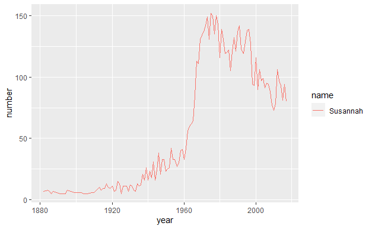

```r
babynames_filtered <- babynames %>%
  filter(name == 'Susannah') %>%
  rename(number = n)
babynames_filtered


ggplot(babynames_filtered,
       aes(x = year, y = number, color = name)) +
      geom_line()
```

#### Filter for multiple names

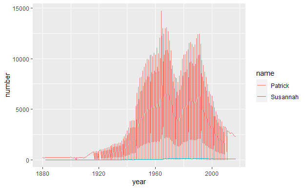

#### When was each name most common?

| year | name | n |
| --- | --- | --- |
| 1880 | Manerva | 10 |
| 1880 | Neppie | 7 |
| 1880 | Arch | 61 |
| 1880 | Redden | 6 |
| 1881 | Zilpah | 9 |
| 1881 | Garfield | 147 |
| 1881 | Ole | 42 |
| 1881 | Chin | 11 |
| 1881 | Roll | 5 |
| 1882 | Crete | 8 |

[output cut: 990 more lines]

### Section 2 - Grouped mutates

```r
babynames %>%
  group_by(year) %>%
  mutate(year_total = sum(n))
```

- Group by - only want to add up within each year
- Mutate - creates a new column called year_total
- Presence of group_by can make other groups or filters slower to run
- Good practice to use ungroup() - as we’ve done what we’re trying to do
- Can then calculate the fraction column

```r
babynames %>%
  group_by(year) %>%
  mutate(year_total = sum(number)) %>%
  ungroup() %>%
  mutate(fraction = number / year_total)
```

- Fractions can make graphs more interpretable

### Section 3 - Window functions

#### Window function

- Takes a vector and returns a vector of the same length
- Using the `lag()` function - moves each item to the right
- This allows for comparison between consecutive steps and calculating the changes

```r
v <- c(1, 3, 6, 14)
v
```

```
[1]  1  3  6 14
```

```r
lag(v)
```

```
[1] NA  1  3  6
```

```r
v - lag(v)  # Difference between two observations
```

```
[1] NA  2  3  8
```

#### Changes in popularity of a name

| year | name | n | year_total | fraction |
| --- | --- | --- | --- | --- |
| 1880 | Mary | 7065 | 201484 | 3.506482e-02 |
| 1880 | Anna | 2604 | 201484 | 1.292410e-02 |
| 1880 | Emma | 2003 | 201484 | 9.941236e-03 |
| 1880 | Elizabeth | 1939 | 201484 | 9.623593e-03 |
| 1880 | Minnie | 1746 | 201484 | 8.665701e-03 |
| 1880 | Margaret | 1578 | 201484 | 7.831887e-03 |
| 1880 | Ida | 1472 | 201484 | 7.305791e-03 |
| 1880 | Alice | 1414 | 201484 | 7.017927e-03 |
| 1880 | Bertha | 1320 | 201484 | 6.551389e-03 |
| 1880 | Sarah | 1288 | 201484 | 6.392567e-03 |

[output cut: 990 more lines]

#### Susannah

```r
babynames_fraction %>%
  filter(name == 'Susannah') %>%
  arrange(year)
```

#### Biggest jump in popularity

| year | name | n | year_total | fraction | difference |
| --- | --- | --- | --- | --- | --- |
| 1967 | Susannah | 113 | 3395130 | 3.328297e-05 | 8.827279e-06 |
| 1887 | Susannah | 7 | 247394 | 2.829495e-05 | 8.711448e-06 |
| 1895 | Susannah | 8 | 351022 | 2.279059e-05 | 8.027832e-06 |
| 2012 | Susannah | 106 | 3650462 | 2.903742e-05 | 7.678758e-06 |
| 1975 | Susannah | 152 | 3019910 | 5.033263e-05 | 7.246317e-06 |
| 1966 | Susannah | 85 | 3475674 | 2.445569e-05 | 6.805526e-06 |
| 1981 | Susannah | 139 | 3459182 | 4.018291e-05 | 6.506396e-06 |
| 2000 | Susannah | 116 | 3778079 | 3.070343e-05 | 5.517498e-06 |
| 1972 | Susannah | 142 | 3143627 | 4.517075e-05 | 5.259142e-06 |
| 1969 | Susannah | 131 | 3476215 | 3.768467e-05 | 4.833504e-06 |

[output cut: 112 more lines]

#### Changes within every name

| year | name | n | year_total | fraction | difference |
| --- | --- | --- | --- | --- | --- |
| 1880 | John | 9655 | 201484 | 0.04791944 | 0.04769113 |
| 1880 | William | 9532 | 201484 | 0.04730897 | 0.04716007 |
| 1881 | John | 8769 | 192696 | 0.04550691 | 0.04537198 |
| 1881 | William | 8524 | 192696 | 0.04423548 | 0.04407979 |
| 1882 | John | 9557 | 221533 | 0.04314030 | 0.04295974 |
| 1882 | William | 9298 | 221533 | 0.04197117 | 0.04183124 |
| 1883 | John | 8894 | 216946 | 0.04099638 | 0.04081200 |
| 1891 | Mary | 11703 | 286672 | 0.04082366 | 0.04070753 |
| 1889 | Mary | 11648 | 288946 | 0.04031203 | 0.04014507 |
| 1890 | Mary | 12078 | 301401 | 0.04007286 | 0.03993096 |

[output cut: 990 more lines]